# Welkom

In 2014 is door de overheid de [Actieagenda Smart Industry](http://www.smartindustry.nl/site/assets/files/1737/smart-industry-actieagenda-lr.pdf) opgesteld. Het doel van de agenda is het Nederlands bedrijfsleven te mobileren en tot de kopgroep in de wereld te laten horen op het gebied van slimme productie.

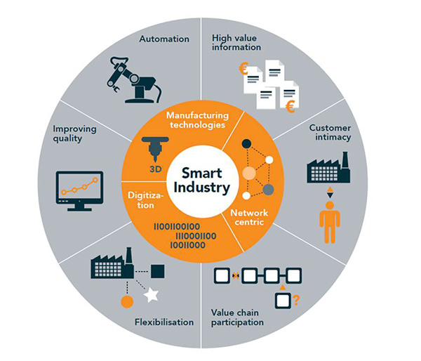

De HAN is momenteel hard aan het werk om een kennislijn *Smart Industry* op te zetten, zowel binnen haar onderzoeks- als haar onderwijsactiviteiten. De minor *Smart Industry* is onderdeel van het geheel aan initiatieven die momenteel worden ontplooid. De opleiding Bedrijfskunde MER heeft de minor geadopteerd en is bezig om deze in samenwerking met de Informatica Communicatie Academie (ICA) op te zetten.

Op **donderdag 17 november 2016** organiseert Bedrijfskunde MER een hackathon, waarbij professionals uit het werkveld worden uitgenodigd om mee te bouwen aan een visie en bijpassend programma voor hoger onderwijs over *Smart Industry*. Doet u mee en helpt u de volgende generatie werknemers voor te bereiden op hun rol binnen de BV Nederland 4.0?

*Witek ten Hove*  
*Coördinator Minor Smart Industry*  
*Hogeschool Arnhem en Nijmegen*